# Treated and highly diluted wastewater impacts diversity and energy fluxes of freshwater food webs

# 4. Community size spectra

In this section we will assess the effects of the effluent on community size-spectra looking at the interaction between period (Before-After) and reach (Control-Impact). For that we will work with a file containing individual body sizes: “Complete_body_size_data.csv”.

## 4.1 Entire community

```r
data <- read.csv("Complete_body_size_data.csv",h=T,sep=";",dec = ".")

data$Period<-factor(data$Period, levels=c("Before","After"))
data$Reach<-factor(data$Reach)
data$BACI <- as.factor(paste(data$Period,data$Reach,sep="_"))
data$ID<-as.factor(paste(data$Campaign, data$Reach,data$Sample, sep="_"))
    data<-subset(data,!(data$ID=="Oct'16_Control_9"))
str(data)

#Threshold for the smallest individual
data$mass <- exp(data$LN.BM.)
data <- data[which(data$mass>0.1),]#exclude individuals with BM smaller than 0.1
data$log10mass <- log(data$mass,10)#create log10mass vector
```

```r
#Entire community size spectrum====
cutter <- function(x, breaks=8) {#decide the ammount of breaks so that we don't get many empty boxes #check the dimensions and we know how many baci cases we have and how many boxes we are asking for
  r <- range(x)
  b <- seq(r[1], r[2], length=2*breaks+1)
  brk <- b[0:breaks*2+1]
  mid <- b[1:breaks*2]
  brk[1] <- brk[1]-0.01
  k <- cut(x, breaks=brk, labels=FALSE)
  mid[k]
}

# adds a column to the df called bin with the bin centre information
data <- within(data,{
  bin <- ave(log10mass,BACI,FUN=cutter)
})


# Calculate the total abundance in each size class
data$dilution<-rep(1/(0.09*9), length(data$log10mass))
data$dilution[!(data$Org.type=="Fish") & data$Period=="Before"] <- 1/(0.09*9)#Replace the dilution in inverts knowing the sample ammount (we had 9 samples in Oct16I, 9 & oct17C, but 8 in oct16C & oct17)
data$dilution[!(data$Org.type=="Fish") & data$Period=="After" & data$Reach=="Impact"] <- 1/(0.09*8)#Replace the dilution in inverts knowing the sample ammount
data$dilution[!(data$Org.type=="Fish") & data$Period=="Before" & data$Reach=="Control"] <- 1/(0.09*8)#Replace the dilution in inverts knowing the sample ammount

#The dilution in fish depends as well on the sampled area
data$dilution[data$Org.type=="Fish" & data$Period=="Before" & data$Reach=="Control"] <- 1/215.818181818182
data$dilution[data$Org.type=="Fish" & data$Period=="Before" & data$Reach=="Impact"] <- 1/208.818181818182
data$dilution[data$Org.type=="Fish" & data$Period=="After" & data$Reach=="Control"] <- 1/225.909090909091
data$dilution[data$Org.type=="Fish" & data$Period=="After" & data$Reach=="Impact"] <- 1/229.181818181818


res <- ddply(data, .(BACI,bin), #split info according to baci into bins
             summarise, log.freq=log(sum(dilution),10),#consider the dilution
             sp.rich=length(unique(Taxa)))#count the amount of taxa in each case
#res$bin<-res$bin-mean(res$bin)
res$log.sp.rich <- log(res$sp.rich,10)
str(res)
res$BACI <- factor(res$BACI)#convert BACI into a factor
names(res)
    res$Period <- sub("_.*", "", res$BACI)
    res$Period <-as.factor(res$Period)
    res$Reach <- sub(".*_", "", res$BACI)
    res$Reach <-as.factor(res$Reach)
summary(res)
```

```r
#Extract parameters and Confidence intervals----
library(plyr)
library(lme4)
parametALL<-lmList(log.freq~bin|BACI, res,pool= FALSE)
coef.summary <- data.frame(coef(parametALL))
confint1 <- t(data.frame(confint(parametALL)))
summary(parametALL)
## Call:
##   Model: log.freq ~ bin | NULL
##    Data: res
##
## Coefficients:
##    (Intercept)
##                Estimate Std. Error   t value     Pr(>|t|)
## After_Control  3.193046  0.2603640 12.263776 1.790362e-05
## After_Impact   3.170816  0.1813507 17.484446 2.245065e-06
## Before_Control 2.615686  0.4006851  6.528035 6.168639e-04
## Before_Impact  3.009412  0.1493109 20.155342 9.688245e-07
##    bin
##                  Estimate Std. Error    t value     Pr(>|t|)
## After_Control  -0.9411553 0.10085242  -9.332005 8.578937e-05
## After_Impact   -1.0091997 0.08133778 -12.407516 1.673347e-05
## Before_Control -0.9541951 0.17662241  -5.402458 1.660029e-03
## Before_Impact  -1.0675599 0.06388007 -16.711939 2.930248e-06
summary(res)
##              BACI        bin             log.freq          sp.rich
##  After_Control :8   Min.   :-0.6700   Min.   :-1.7519   Min.   : 1.00
##  After_Impact  :8   1st Qu.: 0.5138   1st Qu.: 0.2806   1st Qu.: 4.00
##  Before_Control:8   Median : 1.7757   Median : 1.3003   Median : 5.50
##  Before_Impact :8   Mean   : 1.7497   Mean   : 1.2623   Mean   :12.91
##                     3rd Qu.: 3.1155   3rd Qu.: 2.7485   3rd Qu.:20.75
##                     Max.   : 4.5333   Max.   : 3.5539   Max.   :39.00
##   log.sp.rich        Period       Reach
##  Min.   :0.0000   After :16   Control:16
##  1st Qu.:0.6021   Before:16   Impact :16
##  Median :0.7386
##  Mean   :0.9033
##  3rd Qu.:1.3162
##  Max.   :1.5911
#Abundance comparison
res$Period <- factor(res$Period,levels=c("Before","After"))
modeleca <- lm(log.freq ~ bin*Period*Reach,data=res)
anova(modeleca)
## Analysis of Variance Table
##
## Response: log.freq
##                  Df Sum Sq Mean Sq  F value    Pr(>F)
## bin               1 77.482  77.482 304.2028 3.902e-15 ***
## Period            1  1.537   1.537   6.0330   0.02166 *
## Reach             1  0.005   0.005   0.0202   0.88811
## bin:Period        1  0.040   0.040   0.1572   0.69524
## bin:Reach         1  0.169   0.169   0.6649   0.42284
## Period:Reach      1  0.226   0.226   0.8875   0.35554
## bin:Period:Reach  1  0.010   0.010   0.0398   0.84359
## Residuals        24  6.113   0.255
## ---
## Signif. codes:  0 '***' 0.001 '**' 0.01 '*' 0.05 '.' 0.1 ' ' 1
modeleca
##
## Call:
## lm(formula = log.freq ~ bin * Period * Reach, data = res)
##
## Coefficients:
##                 (Intercept)                          bin
##                     2.61569                     -0.95420
##                 PeriodAfter                  ReachImpact
##                     0.57736                      0.39373
##             bin:PeriodAfter              bin:ReachImpact
##                     0.01304                     -0.11336
##     PeriodAfter:ReachImpact  bin:PeriodAfter:ReachImpact
##                    -0.41596                      0.04532
```

## 4.2 Each trophic group

```r
 #Lets get sp in each feeding group:primcons, omnivores, carnivores (considering fish+invertebrates)
#Prepare the datasets with the individuals from each trophic group
    Fgroups<-read.csv("Elgoibar_FFG_from_matrix1.csv",h=T,sep=";",dec=".",na.string=c("NA"))#make sure the names do also match
    #sort(unique(Fgroups$group))
        Fgroups$group<-as.factor(Fgroups$group)
        Fgroups$Consumer<-as.factor(Fgroups$Consumer)
    primconsdf<-subset(Fgroups,Fgroups$group=="primcons")
        primcons<-droplevels(primconsdf$Consumer)
    omnivoredf<-subset(Fgroups,Fgroups$group=="omnivore")
        omnivores<-droplevels(omnivoredf$Consumer)
    carnivoredf<-subset(Fgroups,Fgroups$group=="carnivore")
        carnivores<-droplevels(carnivoredf$Consumer)
    resdf<-subset(Fgroups,Fgroups$group=="Res")
        res<-droplevels(resdf$Consumer)
    #check which ones are T/F for each group
    local.primcons <- data$Taxa %in% primcons#We'll keep the sp of the matrix only present in the local sp list
    local.omnivores<-data$Taxa%in% omnivores
    local.carnivores<-data$Taxa%in% carnivores
    data$primcons<-local.primcons
    data$omnivores<-local.omnivores
    data$carnivores<-local.carnivores
dataFgroups<-data
listTGsizespectra <- list()#create a list to keep them all
    #create the required df
    primconsoct<-subset(data,data$primcons=="TRUE")
      primconsoct$Consumer<-" Primary consumers"
      listTGsizespectra[[1]] <- primconsoct#keep the df in the list we have created
    omnioct<-subset(data,data$omnivores=="TRUE")
      omnioct$Consumer<-"Omnivores"
      listTGsizespectra[[2]] <- omnioct#keep the df in the list we have created
    carnioct<-subset(data,data$carnivores=="TRUE")
      carnioct$Consumer<-"Carnivores"
      listTGsizespectra[[3]] <- carnioct#keep the df in the list we have created

#We have previously selected number of breaks looking at empty bins and Adjusted Rsq #
#8 will be the amount of bins for all the Trophic groups

for(i in 1:length(listTGsizespectra)){
  dataTG <- listTGsizespectra[[i]]
  cutter <- function(x, breaks=8) {#decide the ammount of breaks so that we don't get many empty boxes #check the dimensions and we know how many baci cases we have and how many boxes we are asking for
    r <- range(x)
    b <- seq(r[1], r[2], length=2*breaks+1)
    brk <- b[0:breaks*2+1]
    mid <- b[1:breaks*2]
    brk[1] <- brk[1]-0.01
    k <- cut(x, breaks=brk, labels=FALSE)
    mid[k]
  }

  # this adds a column to data called bin which is you bin centre
  dataTG <- within(dataTG,{
    bin <- ave(log10mass,BACI,FUN=cutter)
  })



  # Calculate the total abundance in each size class
  dataTG$dilution<-rep(1/(0.09*9), length(dataTG$log10mass))
  dataTG$dilution[!(dataTG$Org.type=="Fish") & dataTG$Period=="Before"] <- 1/(0.09*9)#Replace the dilution in inverts knowing the sample ammount (usually 9, but oct16 control and oct17 I 8)
  dataTG$dilution[!(dataTG$Org.type=="Fish") & dataTG$Period=="After" & dataTG$Reach=="Impact"] <- 1/(0.09*8)#Replace the dilution in inverts knowing the sample ammount
  dataTG$dilution[!(dataTG$Org.type=="Fish") & dataTG$Period=="Before" & dataTG$Reach=="Control"] <- 1/(0.09*8)#Replace the dilution in inverts knowing the sample ammount

  #The dilution in fish depends as well on the sampled area
  dataTG$dilution[dataTG$Org.type=="Fish" & dataTG$Period=="Before" & dataTG$Reach=="Control"] <- 1/215.818181818182
  dataTG$dilution[dataTG$Org.type=="Fish" & dataTG$Period=="Before" & dataTG$Reach=="Impact"] <- 1/208.818181818182
  dataTG$dilution[dataTG$Org.type=="Fish" & dataTG$Period=="After" & dataTG$Reach=="Control"] <- 1/225.909090909091
  dataTG$dilution[dataTG$Org.type=="Fish" & dataTG$Period=="After" & dataTG$Reach=="Impact"] <- 1/229.181818181818


  res <- ddply(dataTG, .(BACI,bin), #split info according to baci into bins
               summarise, log.freq=log(sum(dilution),10),#consider the dilution
               sp.rich=length(unique(Taxa)))#count the amount of taxa in each case
  #res$bin<-res$bin-mean(res$bin)
  res$log.sp.rich <- log(res$sp.rich,10)
  #str(res)
  res$BACI <- factor(res$BACI)#convert BACI into a factor
  #names(res)
  res$Period <- as.factor(sub("_.*", "", res$BACI))
  res$Reach <- as.factor(sub(".*_", "", res$BACI))
  #summary(res)

  ##Model for each Trophic group
  #Abundance comparison
  res$Period <- factor(res$Period,levels=c("Before","After"))
  model <- lm(log.freq ~ bin*Period*Reach,data=res)
  print(paste("Model for", unique(dataTG$Consumer)))
  print(anova(model))
  print(model)
  summary(model)#look at the adjusted Rsq
  #str(res)#look at the observation number to find missing bins


  #Extract parameters and Confidence intervals----
  #For abundance====
  parametALL<-lmList(log.freq~bin|BACI, res,pool= FALSE)
  coef.summary <- data.frame(coef(parametALL))
  confint1 <- t(data.frame(confint(parametALL)))
  summary(parametALL)

}
```

```
## [1] "Model for  Primary consumers"
## Analysis of Variance Table
##
## Response: log.freq
##                  Df Sum Sq Mean Sq  F value    Pr(>F)
## bin               1 9.6136  9.6136 164.5543 3.103e-12 ***
## Period            1 0.6767  0.6767  11.5835  0.002338 **
## Reach             1 0.0076  0.0076   0.1306  0.720998
## bin:Period        1 0.3507  0.3507   6.0032  0.021951 *
## bin:Reach         1 0.1002  0.1002   1.7146  0.202782
## Period:Reach      1 0.6125  0.6125  10.4848  0.003502 **
## bin:Period:Reach  1 0.1211  0.1211   2.0720  0.162942
## Residuals        24 1.4021  0.0584
## ---
## Signif. codes:  0 '***' 0.001 '**' 0.01 '*' 0.05 '.' 0.1 ' ' 1
##
## Call:
## lm(formula = log.freq ~ bin * Period * Reach, data = res)
##
## Coefficients:
##                 (Intercept)                          bin
##                      2.0740                      -0.7764
##                 PeriodAfter                  ReachImpact
##                      0.5395                       0.3775
##             bin:PeriodAfter              bin:ReachImpact
##                      0.1228                      -0.3223
##     PeriodAfter:ReachImpact  bin:PeriodAfter:ReachImpact
##                     -0.6360                       0.3474
##
## [1] "Model for Omnivores"
## Analysis of Variance Table
##
## Response: log.freq
##                  Df  Sum Sq Mean Sq  F value    Pr(>F)
## bin               1 14.4639 14.4639 245.3422 4.215e-14 ***
## Period            1  0.7687  0.7687  13.0392 0.0013989 **
## Reach             1  1.2469  1.2469  21.1498 0.0001152 ***
## bin:Period        1  0.0505  0.0505   0.8571 0.3637542
## bin:Reach         1  0.2350  0.2350   3.9853 0.0573636 .
## Period:Reach      1  0.0907  0.0907   1.5380 0.2269012
```

[output cut: 31 more lines]

```
## ---
## Signif. codes:  0 '***' 0.001 '**' 0.01 '*' 0.05 '.' 0.1 ' ' 1
##
## Call:
## lm(formula = log.freq ~ bin * Period * Reach, data = res)
##
## Coefficients:
##                 (Intercept)                          bin
##                     1.09965                     -0.27676
##                 PeriodAfter                  ReachImpact
##                     0.45242                      0.17505
##             bin:PeriodAfter              bin:ReachImpact
##                    -0.02441                     -0.09006
##     PeriodAfter:ReachImpact  bin:PeriodAfter:ReachImpact
##                    -0.22298                      0.04808
```

# 5. Code for plots

**Code for plots, click here to expand**

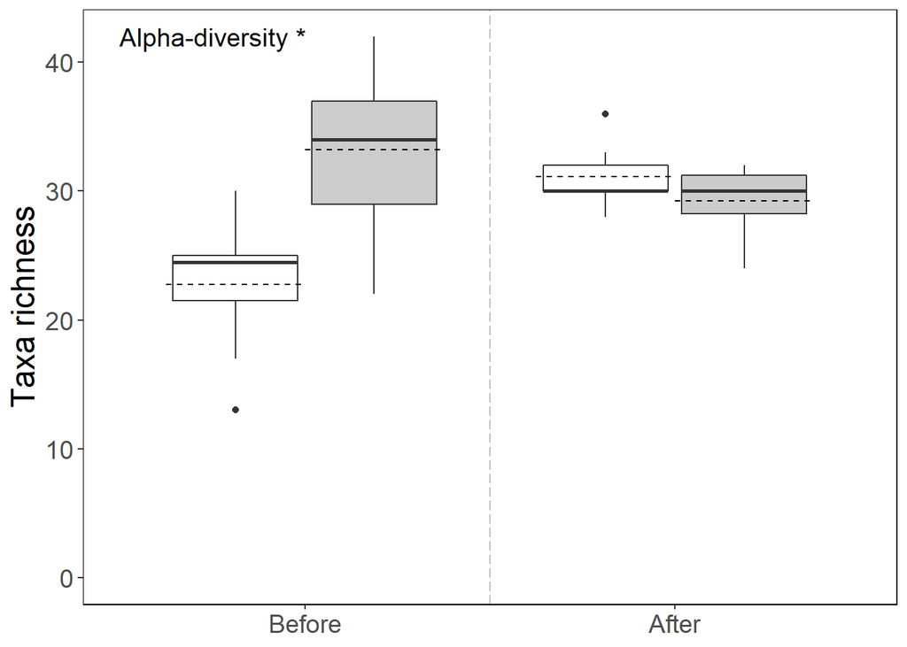

```r
pH0_a<-ggplot(df_alfa, aes(x=Period, y=Hill_0, fill=Reach))+#group = interaction(Campaign, as.factor(Reach)
      geom_boxplot()+scale_fill_manual(values=c("white", "grey80"))+
      stat_summary(fun = mean, geom = "errorbar", aes(ymax = ..y.., ymin = ..y.., group = factor(Reach)), width = 0.75, linetype = "dashed", position = position_dodge())+
      #ggtitle(label = levels(df$functions)[i]) +
      #ylim(min(log(sub$Sum_of_fluxes,10)),(max(log(sub$Sum_of_fluxes,10))+0.1))+
      ylim(0,max(df_alfa$Hill_0))+
      my_theme+
      theme(legend.position="none")+
      xlab(NULL)  +
      ylab("Taxa richness")+
      #stat_compare_means(method = "anova")+#,label.x=2.75, label.y=1.39)+
      geom_vline(xintercept = 1.5, linetype="longdash", color = "gray75", size=0.5)+
      #annotate("text", x=0.55, y=(max(log(sub$Sum_of_fluxes,10))+0.1), label= unique(sub$picID), size = 6)
      annotate("text", x=0.5, y=max(df_alfa$Hill_0), label= "Alpha-diversity *", size = 5,hjust = 0)

#to merge the plots
    #grid.arrange(pH0_a,pH0_b,pH1_a,pH1_b,pH2_a,pdens, nrow =3, ncol =2)
```

# References

The analyses presented here were conducted with the fundamental aid of the next references:

- Brown, James H, James F Gillooly, Andrew P Allen, Van M Savage, and Geoffrey B West. 2004. “Toward a Metabolic Theory of Ecology.” Ecology 85 (7): 1771-89. https://doi.org/10.1890/03-9000.
- Gauzens, Benoit, Andrew Barnes, Darren P Giling, Jes Hines, Malte Jochum, Jonathan S Lefcheck, Benjamin Rosenbaum, Shaopeng Wang, and Ulrich Brose. 2019. “Fluxweb: An R Package to Easily Estimate Energy Fluxes in Food Webs.” Methods in Ecology and Evolution 10 (2): 270-79.
- Lang, Birgit, Roswitha B Ehnes, Ulrich Brose, and Björn C Rall. 2017. “Temperature and Consumer Type Dependencies of Energy Flows in Natural Communities.” Oikos 126 (12): 1717-25. https://doi.org/10.1111/oik.04419.
- Marcon, Eric, and Bruno Hérault. 2015. “Entropart: An R Package to Measure and Partition Diversity.” Journal of Statistical Software 67 (8): 1-26. https://doi.org/10.18637/jss.v067.i08.
- Soetaert, Karline, and Julius Kipyegon Kones. 2014. “Package NetIndices, Network Indices and Food Web Descriptors In R.
[^1]: University of the Basque Country (UPV/EHU), mirenioar.deguzman@ehu.eus
[^2]: University of the Basque Country (UPV/EHU)
[^3]: University of Barcelona
[^4]: Rey Juan Carlos University
[^5]: Universidad Nacional del Centro de la Provincia de Buenos Aires, CONICET; Universidad Nacional de La Plata
[^6]: German Centre for Integrative Biodiversity Research (iDiv) Halle-Jena- Leipzig; University of Jena
[^7]: French National Center for Scientific Research